# Analysis on LendingClub’s Loan Data

## 3.3 Data Preparation for Heatmap Analysis

```r
# Create income brackets
# Create income brackets
df_final <- df_final %>%
  mutate(income_bracket = cut(annual_inc,
                              breaks = quantile(annual_inc, probs = seq(0, 1, 0.2), na.rm = TRUE),
                              labels = c('Very Low', 'Low', 'Medium', 'High', 'Very High'),
                              include.lowest = TRUE))

# Reorder income_bracket factor levels
df_final$income_bracket <- factor(df_final$income_bracket,
                              levels = c('Very High', 'High', 'Medium', 'Low', 'Very Low'))

# Calculate repayment rates
repayment_rates <- df_final %>%
  group_by(grade, income_bracket) %>%
  summarize(repayment_rate = mean(loan_status_binary, na.rm = TRUE)) %>%
  pivot_wider(names_from = income_bracket, values_from = repayment_rate)

# Display the repayment rates
print(repayment_rates)
```

```
## # A tibble: 7 × 6
## # Groups:   grade [7]
##   grade `Very High`  High Medium   Low `Very Low`
##   <chr>       <dbl> <dbl>  <dbl> <dbl>      <dbl>
## 1 A           0.950 0.945  0.939 0.936      0.914
## 2 B           0.881 0.873  0.866 0.861      0.846
## 3 C           0.800 0.784  0.769 0.765      0.755
## 4 D           0.732 0.701  0.686 0.676      0.676
## 5 E           0.662 0.622  0.590 0.584      0.599
## 6 F           0.602 0.544  0.526 0.516      0.522
## 7 G           0.571 0.499  0.482 0.460      0.461
```

```r
rm(heatmap_data)
```

## 3.4 Repayment Rate by Grade and Income Bracket

### 3.4.1 HEATMAP

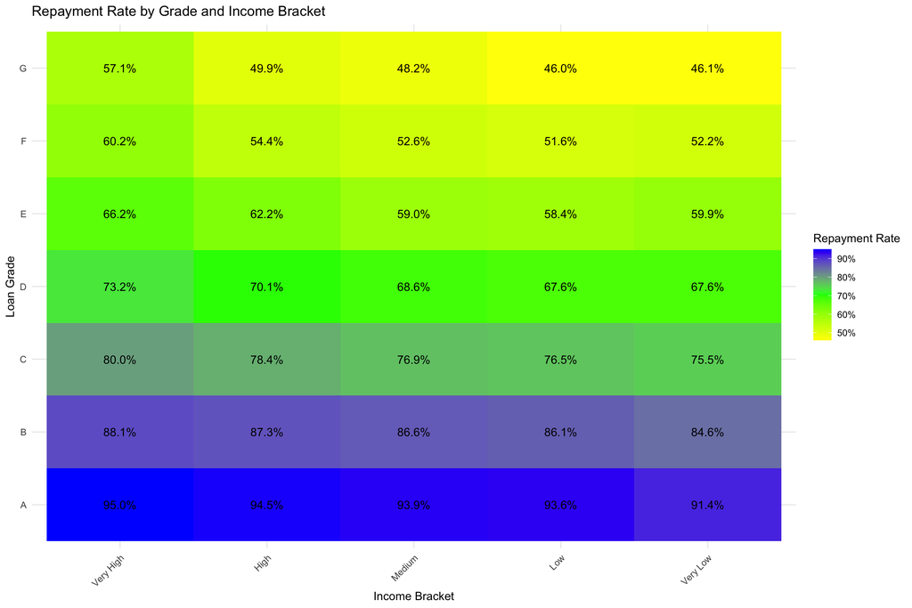

```r
# Prepare data for heatmap
heatmap_data <- repayment_rates %>%
  pivot_longer(cols = -grade, names_to = "income_bracket", values_to = "repayment_rate")

# Ensure income_bracket is a factor with correct order
heatmap_data$income_bracket <- factor(heatmap_data$income_bracket,
                                      levels = c('Very High', 'High', 'Medium', 'Low', 'Very Low'))

# Create heatmap
ggplot(heatmap_data, aes(x = income_bracket, y = grade, fill = repayment_rate)) +
  geom_tile() +
  geom_text(aes(label = scales::percent(repayment_rate, accuracy = 0.1)), color = "black") +
  scale_fill_gradientn(colors = c("yellow", "green", "blue"),
                       labels = scales::percent_format(accuracy = 1),
                       name = "Repayment Rate") +
  labs(title = "Repayment Rate by Grade and Income Bracket",
       x = "Income Bracket",
       y = "Loan Grade") +
  theme_minimal() +
  theme(axis.text.x = element_text(angle = 45, hjust = 1))
```

```r
rm(heatmap_data)
rm(repayment_rates)
```

–Grade is the primary determinant of repayment: There’s a clear vertical gradient showing that loan grade has a stronger influence on repayment rates than income. Grade A loans consistently have the highest repayment rates (91-95%) across all income brackets, while Grade G loans have the lowest (46-57%)

–Income impact varies by grade: For higher-grade loans (A-C), income has minimal effect on repayment rates. However, for lower-grade loans (D-G), there’s a more noticeable positive correlation between income and repayment rates, particularly for the “Very High” income bracket.